# Swiftkey Word Prediction

Sheng Feng

4/9/2017

## Introduction

This is the capstone project for the Data Science Specialization. In this work we foucs on Natural Languange Processing and word prediction.

## Loading data

Here we load the data from the [original dataset](https://d396qusza40orc.cloudfront.net/dsscapstone/dataset/Coursera-SwiftKey.zip), make a sample that consists 20% of the records, and save the samples.

```r
set.seed(5832)

processFile <- function(filepath, sampleProp) {
  df = data.frame(readLines(filepath))
  return(sample_frac(df, sampleProp))
}


dir.create(file.path(".", "sample"), showWarnings = FALSE)
if(!file.exists("sample/twitter_sample.txt")){
  twsample <- processFile("final/en_US/en_US.twitter.txt", 0.2)
  write.table(twsample, "sample/twitter_sample.txt", row.names = FALSE, col.names = FALSE, quote = FALSE)
}
if(!file.exists("sample/blogs_sample.txt")){
  blogsample <- processFile("final/en_US/en_US.blogs.txt",  0.2)
  write.table(blogsample, "sample/blogs_sample.txt", row.names = FALSE, col.names = FALSE, quote = FALSE)
}
if(!file.exists("sample/news_sample.txt")){
  newsample <- processFile("final/en_US/en_US.news.txt", 0.2)
  write.table(newsample, "sample/news_sample.txt", row.names = FALSE, col.names = FALSE, quote = FALSE)
}
```

Here we devides the sample into three subset by 60% / 20% / 20%, and use them as training, testing and validation sets respectively.

```r
if(!file.exists("data/training.rds")){
  tw <- readLines("sample/twitter_sample.txt")
  bl <- readLines("sample/blogs_sample.txt")
  nw <- readLines("sample/news_sample.txt")
  text = c(tw, bl, nw)
  Encoding(text) <- "UTF-8"
  # docs <- text %>% strsplit(split = "(?!')[[:punct:]]", perl = TRUE) %>% unlist() %>%data_frame(text = .) %>% filter(!text == "")
  docs <- data_frame(text)
  set.seed(4869)
  intrain <- sample(nrow(docs), 0.6 * nrow(docs))
  training <- docs[intrain,]
  dir.create(file.path(".", "data"), showWarnings = FALSE)
  saveRDS(training, "data/training.rds")
  testing <- docs[-intrain, ]
  invalid <- sample(nrow(testing), 0.5 * nrow(testing))
  validating <- testing[invalid,]
  testing <- testing[-invalid,]
  saveRDS(validating, "data/validating.rds")
  saveRDS(testing, "data/testing.rds")
} else{
  training <- readRDS("data/training.rds")
}
```

## Bad Words

```r
bad.words <- read.csv("bad-words.txt", col.names = c("word"),header = FALSE)
```

## Unigram Exploration

We tokenize the text samples into words, remove the bad words and stop words, and do some exploratory analysis.

```r
unigram <- training %>% unnest_tokens(word, text) %>%
    filter(!grepl("[+-]?([0-9]*[.])?[0-9]+", word)) %>%
      count(word) %>%
          anti_join(bad.words) %>%
            ungroup() %>%
              arrange(desc(n))
data(stop_words)
tidystop <- unigram %>% anti_join(stop_words)
```

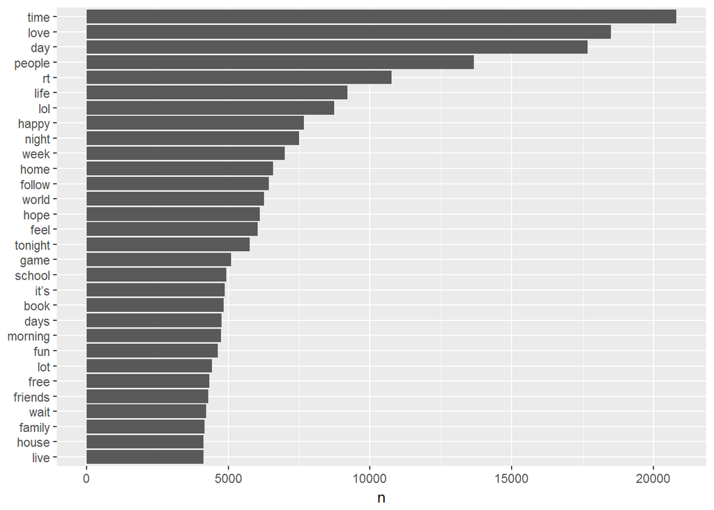

```r
tidystop %>%
   .[1:30,] %>%
   mutate(word = reorder(word, n)) %>%
   ggplot(aes(word, n)) +
   geom_col() +
   xlab(NULL) +
   coord_flip()
```

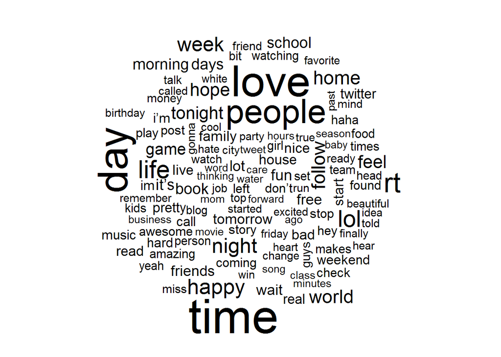

```r
library(wordcloud)
tidystop %>%
  with(wordcloud(word, n, max.words = 120))
```

```r
library(reshape2)
```

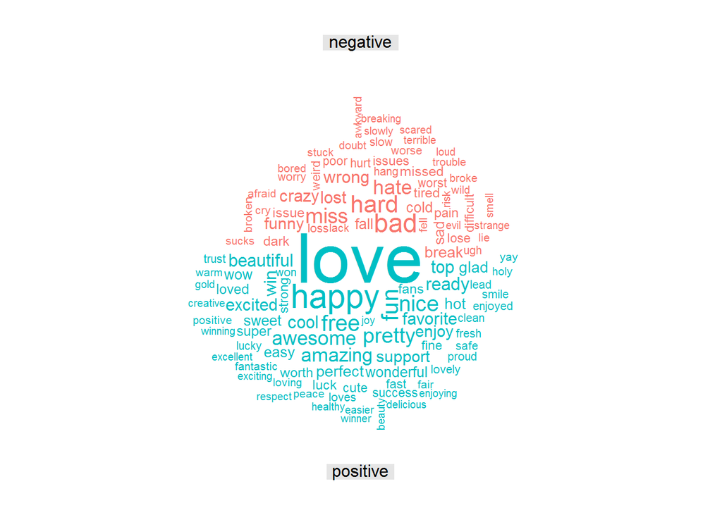

```r
tidystop %>%
 inner_join(get_sentiments("bing")) %>%
  count(word, sentiment, sort = TRUE) %>%
  acast(word ~ sentiment, value.var = "n", fill = 0) %>%
  comparison.cloud(colors = c("#F8766D", "#00BFC4"),
                   max.words = 120,title.size=1)
```

## Generating n-grams

We tokenize the text into bigrams, trigrams and quadgrams, and remove the tokens that contain bad words as output. We do not remove the stop words since they would be valid predictions.

```r
ngram <- function(text, n){
  text %>% unnest_tokens(ngram, text, token = "ngrams", n = n) %>%
    filter(!grepl("[+-]?([0-9]*[.])?[0-9]+", ngram)) %>%
      count(ngram) %>%
       extract(ngram, into = c("first", "last"), '(.*)\\s+([^ ]+)$') %>%
          anti_join(bad.words, by = c("last" = "word"))%>%
            ungroup() %>%
              arrange(desc(n))
}

bigram <- ngram(training, 2)
trigram <- ngram(training, 3)
quadgram <- ngram(training, 4)
```

## Good-Turing Discount

```r
calcDiscount <- function(ngramTable){

  freqTable <- ngramTable %>% group_by(n) %>% summarise(count = n()) %>% ungroup() %>% arrange(n)
  freqTable$discount <- 1
  for(i in 1:5){
    currN = freqTable$count[i]
    nextN = freqTable$count[i + 1]
    freqTable$discount[i] <- (i + 1)/i * (nextN / currN)
  }
  freqTable <- freqTable %>% select(n, discount)
  ngramTable %>% select(first, last, n) %>% left_join(freqTable) %>% ungroup()
}

bigramTable <- calcDiscount(bigram)
trigramTable <- calcDiscount(trigram)
quadgramTable <- calcDiscount(quadgram)
unigram$p = unigram$n / sum(unigram$n)
```

```r
dir.create(file.path(".", "ngrams"), showWarnings = FALSE)
saveRDS(unigram, "ngrams/unigrams.rds")
saveRDS(bigramTable, "ngrams/bigrams.rds")
saveRDS(trigramTable, "ngrams/trigrams.rds")
saveRDS(quadgramTable, "ngrams/quadgrams.rds")
```

## Calculate Conditional Probability with Katz Backoff

```r
calcProb <- function(f, l, n){
  three = tail(unlist(strsplit(f," ")),3)
  leftover <- 1
  quadtab <- quadgramTable %>% filter(first == paste(three, collapse = " "))
  r <-  quadtab %>% filter(last == l)
  if (nrow(r) > 0) {
    # print("quadgram hit!")
    d = r$discount[1]
    n = r$n[1]
    return(d * n / sum(quadtab$n))
  }

  if (nrow(quadtab) > 1)
    leftover <-  1 - sum(quadtab$discount * quadtab$n) / sum(quadtab$n)

  tritab <- trigramTable %>% filter(first == paste(tail(three,2), collapse = " "))
  tritab <- tritab %>% anti_join(quadtab, by = "last")
  r <-  tritab %>% filter(last == l)
  if (nrow(r) > 0) {
    # print("trigram hit!")
    d = r$discount[1]
    n = r$n[1]
    return(leftover * d * n / sum(tritab$n))
  }

  if (nrow(tritab) > 1)
    leftover <-  leftover * ( 1 - sum(tritab$discount * tritab$n) / sum(tritab$n))

  bitab <- bigramTable %>% filter(first == tail(three, 1))
  bitab <- bitab %>% anti_join(quadtab, by = "last")
  bitab <- bitab %>% anti_join(tritab, by = "last")
  r <-  bitab %>% filter(last == l)
  if (nrow(r) > 0) {
    print("bigram hit!")
    d = r$discount[1]
    n = r$n[1]
    return(leftover * d * n / sum(bitab$n))
  }

  leftover <- leftover * ( 1 - sum(bitab$discount * bitab$n) / sum(bitab$n))

  return(leftover * filter(unigram, word == l)$p)
}

calcProb("i am", "a")
```

```
## [1] 0.05531674
```

## Make prediction

```r
backoffPred <- function(f){
  three = tail(unlist(strsplit(f," ")),3)
  leftover <- 1.0

  pred = data_frame()
  quadtab <- quadgramTable %>% filter(first == paste(three, collapse = " "))

  if (nrow(quadtab) > 0) {
    # print("quadgram hit!")
    pred <- quadtab %>% mutate(prob = n * discount / sum(quadtab$n)) %>% select(last, prob)
    leftover <-  1 - sum(pred$prob)
    if (leftover < 0.1)
      return(pred %>% arrange(desc(prob)) %>% head(10))
  }


  tritab <- trigramTable %>% filter(first == paste(tail(three,2), collapse = " ")) %>% anti_join(quadtab, by = "last")

  if (nrow(tritab) > 0) {
    # print("trigram hit!")
    pred <- rbind(pred, tritab %>% mutate(prob = leftover * n * discount / sum(tritab$n)) %>% select(last, prob))
    leftover <-  1 - sum(pred$prob)
    if (leftover < 0.1)
      return(pred %>% arrange(desc(prob)) %>% head(10))
  }

  bitab <- bigramTable %>% filter(first == tail(three, 1)) %>% anti_join(quadtab, by = "last") %>% anti_join(tritab, by = "last")

  if (nrow(bitab) > 0) {
    # print("bigram hit!")
    pred <- rbind(pred, bitab %>% ungroup() %>% mutate(prob = leftover * n * discount / sum(bitab$n)) %>% select(last, prob))
  }

  return(pred %>% arrange(desc(prob)) %>% head(10))
}

backoffPred("this is a")
```

| last | prob |
| --- | --- |
| great | 0.0655926 |
| good | 0.0517837 |
| very | 0.0322209 |
| free | 0.0212891 |
| lot | 0.0212891 |
| perfect | 0.0212891 |
| beer | 0.0212891 |
| dangerous | 0.0212891 |
| big | 0.0126582 |
| joke | 0.0122660 |

```r
set.seed(3825)
testing <- readRDS("data/testing.rds")
quadgram <- ngram(testing, 4)
```

## Referece

[tidytext](http://tidytextmining.com/)  
[ngram](https://en.wikipedia.org/wiki/N-gram)  
[katz’s back off](https://en.wikipedia.org/wiki/Katz%27s_back-off_model)  
[bad words](https://www.cs.cmu.edu/~biglou/resources/) [smoothing and discount](https://nlp.stanford.edu/~wcmac/papers/20050421-smoothing-tutorial.pdf) [CS498JH Introduction to NLP](https://courses.engr.illinois.edu/cs498jh/syllabus.html)